# continue…..

```r
knitr::opts_chunk$set(echo = TRUE, dev = "png")
```

## 7. Data analysis

First we will load all the libraries that we will need to perform our data analysis:

```r
library(tidyverse)
library(caret)
library(ade4) # PCA
library(made4) # PCA
library(scatterplot3d) # PCA
library(admisc) # Read radar objects
library(omicade4) # CCA
library(gbm) # Boosting
library(randomForest) # Random Forest
library(xgboost) # XgBoost
library(data.table) # for setnames (in random forest)
library(DMwR) # SMOTE -> remotes::install_github("cran/DMwR")
```

#### **Chronic obstructive pulmonary disease (COPD)**

Chronic obstructive pulmonary disease (COPD) is a long-term lung illness in which the lungs’ small airways are damaged, making it difficult for air to enter and exit.

COPD patients commonly experience one or more of the following symptoms:

- having trouble breathing
- prolonged cough (more than 3 months)
- a cough with mucus most days
- wheezing (a whistling sound when you breathe)
- chest tightness

Shortness of breath is the most common symptom of COPD. Simple daily tasks like walking short distances or walking a stairway might cause COPD sufferers to become out of breath. Even at rest, breathing might become difficult as the condition progresses.

Long-term cigarette smoking is the most common cause of COPD. The more cigarettes you smoke, the more likely you are to get COPD.

### 7.1 Clinical data cleaning

Before we begin with our analysis, we need to explore our clinical data and clean it.

View data:

```r
clinic_data <- read.delim("eclipse_all.txt")
print(as_tibble(clinic_data))
```

```
## # A tibble: 2,671 × 193
##     ...1 INVID.t1 CENTREID.t1 SUBJID.t1       id   AGE SEX.t1 TRTCD.t1 TRTGRP.t1
##    <int>    <int>       <int>     <int>    <dbl> <int> <chr>     <int> <chr>
##  1     2    44783       23140         2  2.31e10    49 F             3 Non-smok…
##  2     3    44783       23140         3  2.31e10    44 F             3 Non-smok…
##  3     4    44783       23140         4  2.31e10    47 F             3 Non-smok…
##  4     5    44783       23140         5  2.31e10    70 F             1 COPD Sub…
##  5     6    44783       23140         6  2.31e10    57 F             1 COPD Sub…
##  6     7    44783       23140         7  2.31e10    51 F             1 COPD Sub…
##  7     8    44783       23140         8  2.31e10    55 M             1 COPD Sub…
##  8     9    44783       23140         9  2.31e10    63 M             1 COPD Sub…
##  9    10    44783       23140        10  2.31e10    66 M             1 COPD Sub…
## 10    11    44783       23140        11  2.31e10    63 M             1 COPD Sub…
## # … with 2,661 more rows, and 184 more variables: GOLDCD <int>, SCRNDT <chr>,
## #   SUPKYR <int>, SUSMYR <int>, COUNTRY <chr>, MMRCCD <int>, RACE1.t1 <chr>,
## #   FFSUBSCR.t1 <dbl>, DWALK.t1 <dbl>, FEV1.t1 <dbl>, FEV1PSDS.t1 <dbl>,
## #   FEV1PSPC.t1 <dbl>, FEV1REV.t1 <dbl>, ICPFT.t1 <dbl>, FVCPSDS.t1 <dbl>,
## #   FEVVCPD.t1 <int>, SVCPFT.t1 <dbl>, FVCPSPC.t1 <dbl>, SGRQCACT.t1 <dbl>,
## #   SGRQCIMP.t1 <dbl>, SGRQCSYM.t1 <dbl>, SGRQCTOT.t1 <dbl>, SGRQTOT.t1 <dbl>,
## #   SGRQSYM.t1 <dbl>, SGRQACT.t1 <dbl>, SGRQIMP.t1 <dbl>, PFATTS.t1 <dbl>, …
```

Delete irrelevant columns:

```r
clinic_data$id <- paste0("0", clinic_data$id) # Add 0 in front of index to match rdr names

clinic_data <- clinic_data[-1] # delete first columns (index 0,1,2...)
row.names(clinic_data) <- clinic_data$id # id as rownames
clinic_data$id <- NULL # delete id colum

clinic_data$SUBJID.t1 <- NULL # index
clinic_data$SCRNDT <- NULL # dates
clinic_data$SUBJID.t3 <- NULL # index
```

Select variables of t1 (data from time 1).

```r
clinical_data_T1 <- dplyr::select(clinic_data, !ends_with("t3"))
```

Check for missing data:

```r
sum(is.na(clinical_data_T1))
```

```
## [1] 37307
```

Delete variables that have more than a 30% of missing values:

```r
more_30_missing <- names(clinical_data_T1[ , colMeans(is.na(clinical_data_T1)) > 0.3])
clinical_data_T1 <- clinical_data_T1[, !colnames(clinical_data_T1) %in% more_30_missing]
```

Impute missing values of double variables for the mean value:

```r
clinical_data_T1 <- clinical_data_T1 %>%  mutate_if(is.double,
                                                    function(x) ifelse(is.na(x), mean(x, na.rm = T), x))
```

```r
clinical_data_T1 <- clinical_data_T1 %>%  mutate_if(is.integer,
                                                    function(x) ifelse(is.na(x), which.max(x), x))
```

Impute missing values of categroical variables for the most common value:

```r
clinical_data_T1[, sapply(clinical_data_T1, function(x) !is.numeric(x))] <- apply(clinical_data_T1[, sapply(clinical_data_T1, function(x) !is.numeric(x))],
                                                      2, function(x) {x[is.na(x)] <- names(sort(table(x), decreasing = TRUE)[1]); x})
```

Check for missing data:

```r
sum(is.na(clinical_data_T1))
```

```
## [1] 0
```

Characters to factors:

```r
ch <- sapply(clinical_data_T1, is.character)
clinical_data_T1[ch] <- lapply(clinical_data_T1[ch], as.factor)
```

Now that we have a clean data set, we will export it:

```r
write.table(clinical_data_T1, file = "eclipse_all_CLEAN.txt", sep = "\t")
```

### 7.2 Principal Component Analysis (PCA)

Recall that PCA is a statistical approach that allows you to summarize the content of big data tables using a smaller set of “summary indices” that are easier to display and study.

**All clinical variables**

Load the clean clinic data set and convert all columns to be numeric (needed for PCA):

```r
clinic_data_clean <- read.delim("eclipse_all_CLEAN.txt")
data <- mutate_all(clinic_data_clean, function(x) as.numeric(as.factor(x)))
data$TRTGRP.t1 <- NULL
data$GOLDCD <- NULL
data[1:5, 1:8]
```

```
##              INVID.t1 CENTREID.t1 AGE SEX.t1 TRTCD.t1 SUPKYR SUSMYR COUNTRY
## 023140000002       36           1  10      1        3    132     66      12
## 023140000003       36           1   5      1        3    132     66      12
## 023140000004       36           1   8      1        3      1      3      12
## 023140000005       36           1  31      1        1     56     40      12
## 023140000006       36           1  18      1        1     22     35      12
```

PCA:

```
## [1] "More than 21 colours selected, some colours maybe replicated"
```

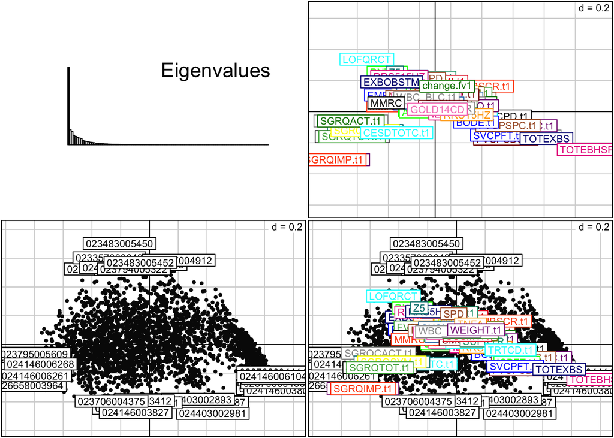

```r
results_PCA <- ord(data, type="coa")
plot(results_PCA, classvec = colnames(data), genecol="grey3")
```

**Differenciate between control (smoker vs non-smoker) and cases (COPD)**

Load data:

```r
clinic_data_clean <- read.delim("eclipse_all_CLEAN.txt")
clinic_data_clean <- mutate_all(clinic_data_clean, function(x) as.numeric(as.factor(x)))
data <- as.data.frame(t(clinic_data_clean))
colnames(data) <- rownames(clinic_data_clean) # put id names

## Label for "COPD" or "Non COPD"
class_vector <- as.numeric(data["TRTGRP.t1",])
for(i in 1:length(class_vector)){
  if(class_vector[i] == 1) class_vector[i] <- "COPD"
  else class_vector[i] <- "Non COPD"
}

## Delete TRTGRP.t1 from table
data <- data[!(row.names(data) %in% "TRTGRP.t1"), ]
data[1:5, 1:8]
```

```
##             023140000002 023140000003 023140000004 023140000005 023140000006
## INVID.t1              36           36           36           36           36
## CENTREID.t1            1            1            1            1            1
## AGE                   10            5            8           31           18
## SEX.t1                 1            1            1            1            1
## TRTCD.t1               3            3            3            1            1
##             023140000007 023140000008 023140000009
## INVID.t1              36           36           36
## CENTREID.t1            1            1            1
## AGE                   12           16           24
## SEX.t1                 1            2            2
## TRTCD.t1               1            1            1
```

PCA:

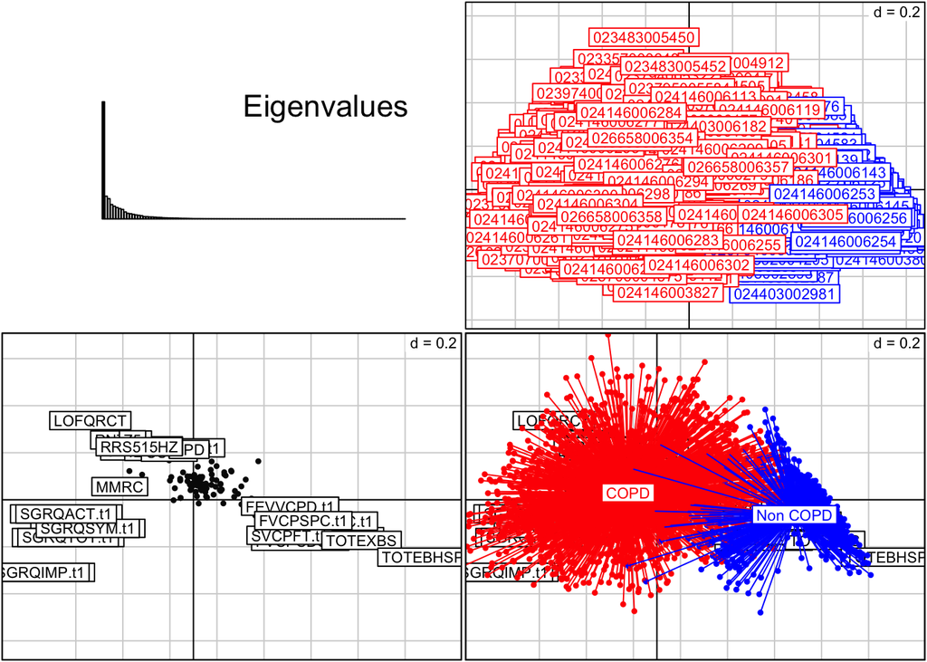

```r
results_PCA <- ord(data, type="coa")
plot(results_PCA, classvec = class_vector, genecol="grey3")
```

**Radiomic features: control (smoker vs non-smoker) and cases (COPD)**

Load radiomic features and clinic data. Since they differ in the number of id, we will only keep common ids.

```r
## Radar object
file <- listRDA("rdr_L1_Andrea.rda")
rdr_L1 <- file$rdr_L1
df_rdr <- as.data.frame(assay(rdr_L1))

## Clinic data
clean_data <- read.delim("eclipse_all_CLEAN.txt")
clean_data <- mutate_all(clean_data, function(x) as.numeric(as.factor(x))) # convert to numeric
df_clinical <- as.data.frame(t(clean_data)) # id as columns
colnames(df_clinical) <- rownames(clean_data)

## Keep common ids
id_in_rdr <- colnames(df_rdr) # id of rdr
id_in_clinical <- colnames(df_clinical) # id of clinical
common_id <- Reduce(intersect, list(id_in_rdr,id_in_clinical)) # common id

df_clinical <- select(df_clinical, one_of(common_id))
df_rdr <- select(df_rdr, one_of(common_id))

## Label for "COPD" or "Non COPD"
class_vector <- as.numeric(df_clinical["TRTGRP.t1",])
for(i in 1:length(class_vector)){
  if(class_vector[i] == 1) class_vector[i] <- "COPD"
  else class_vector[i] <- "Non-COPD"
}

df_rdr[1:5, 1:8]
```

```
##                                  023140000002 023140000003 023140000004
## Elongation.original                 0.7427334    0.6725940    0.6279637
## Flatness.original                   0.5885148    0.6357104    0.5199954
## LeastAxisLength.original          157.7145708  181.3239373  148.1841633
## MajorAxisLength.original          267.9874499  285.2304218  284.9720758
## Maximum2DDiameterColumn.original  273.3002012  280.0803456  273.3002012
##                                  023140000005 023140000006 023140000007
## Elongation.original                 0.8184090    0.8279645    0.8358080
## Flatness.original                   0.6510946    0.6441460    0.5878566
## LeastAxisLength.original          174.1693591  186.8835281  157.3036005
## MajorAxisLength.original          267.5023976  290.1260485  267.5883904
## Maximum2DDiameterColumn.original  292.3183196  328.1737345  300.2215848
##                                  023140000008 023140000009
## Elongation.original                 0.7547735    0.8859727
## Flatness.original                   0.5322810    0.5154954
## LeastAxisLength.original          175.7436695  167.8032369
## MajorAxisLength.original          330.1708555  325.5183918
## Maximum2DDiameterColumn.original  329.8196477  364.7821268
```

PCA:

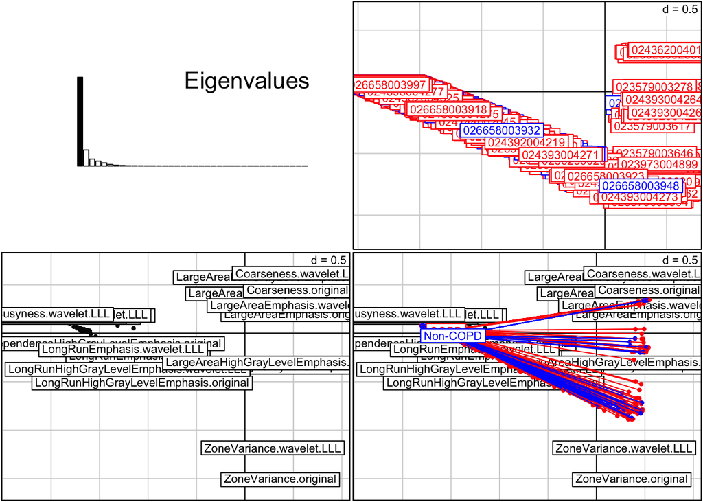

```r
results_PCA <- ord(df_rdr, type="coa")
plot(results_PCA, classvec = class_vector, genecol="grey3")
```

### 7.2 Canonical correlation analysis (CCA)

Now we will analyze the radiomic features against the variables at time T1 using **canonical correlation**.

Canonical correlation analysis (CCA) is a statistical technique for extracting information from cross-covariance matrices. If we have two vectors of random variables, X = (X1,…, Xn) and Y = (Y1,…, Ym), and the variables are correlated, canonical-correlation analysis will find linear combinations of X and Y that have the highest correlation.

Multiple correlation analysis predicts only one dependent variable from several independents, but canonical correlation predicts multiple dependent variables from multiple independents.

In our case, we will have 2 tables. One with the radiomics features, and another one with the clinical data. We want to have id -> columns and features -> rows.

Load radiomic features and clinic data. Since they differ in the number of id, we will only keep common ids.

```r
## Radar object
file <- listRDA("rdr_L1_Andrea.rda")
rdr_L1 <- file$rdr_L1
df_rdr <- as.data.frame(assay(rdr_L1))

## Clinic data
clean_data <- read.delim("eclipse_all_CLEAN.txt")
clean_data <- mutate_all(clean_data, function(x) as.numeric(as.factor(x))) # convert to numeric
df_clinical <- as.data.frame(t(clean_data)) # id as columns
colnames(df_clinical) <- rownames(clean_data)

## Keep common ids
id_in_rdr <- colnames(df_rdr) # id of rdr
id_in_clinical <- colnames(df_clinical) # id of clinical
common_id <- Reduce(intersect, list(id_in_rdr,id_in_clinical)) # common id

df_clinical <- select(df_clinical, one_of(common_id))
df_rdr <- select(df_rdr, one_of(common_id))

## Label for "COPD" or "Non COPD"
class_vector <- as.numeric(df_clinical["TRTGRP.t1",])
for(i in 1:length(class_vector)){
  if(class_vector[i] == 1) class_vector[i] <- "COPD"
  else class_vector[i] <- "Non-COPD"
}

df_clinical <- df_clinical[!(row.names(df_clinical) %in% "TRTGRP.t1"), ] # delete TRTGRP.t1 from table

df_clinical[1:5, 1:8]
```

```
##             023140000002 023140000003 023140000004 023140000005 023140000006
## INVID.t1              36           36           36           36           36
## CENTREID.t1            1            1            1            1            1
## AGE                   10            5            8           31           18
## SEX.t1                 1            1            1            1            1
## TRTCD.t1               3            3            3            1            1
##             023140000007 023140000008 023140000009
## INVID.t1              36           36           36
## CENTREID.t1            1            1            1
## AGE                   12           16           24
## SEX.t1                 1            2            2
## TRTCD.t1               1            1            1
```

```r
df_rdr[1:5, 1:8]
```

```
##                                  023140000002 023140000003 023140000004
## Elongation.original                 0.7427334    0.6725940    0.6279637
## Flatness.original                   0.5885148    0.6357104    0.5199954
## LeastAxisLength.original          157.7145708  181.3239373  148.1841633
## MajorAxisLength.original          267.9874499  285.2304218  284.9720758
## Maximum2DDiameterColumn.original  273.3002012  280.0803456  273.3002012
##                                  023140000005 023140000006 023140000007
## Elongation.original                 0.8184090    0.8279645    0.8358080
## Flatness.original                   0.6510946    0.6441460    0.5878566
## LeastAxisLength.original          174.1693591  186.8835281  157.3036005
## MajorAxisLength.original          267.5023976  290.1260485  267.5883904
## Maximum2DDiameterColumn.original  292.3183196  328.1737345  300.2215848
##                                  023140000008 023140000009
## Elongation.original                 0.7547735    0.8859727
## Flatness.original                   0.5322810    0.5154954
## LeastAxisLength.original          175.7436695  167.8032369
## MajorAxisLength.original          330.1708555  325.5183918
## Maximum2DDiameterColumn.original  329.8196477  364.7821268
```

Combine both data frames into a list.

```r
both_tables <- list("rdr" = df_rdr, "clinical" = df_clinical)
sapply(both_tables, dim) # check the dimension are correct
```

```
##       rdr clinical
## [1,] 1232      117
## [2,] 2227     2227
```

Perform CCA:

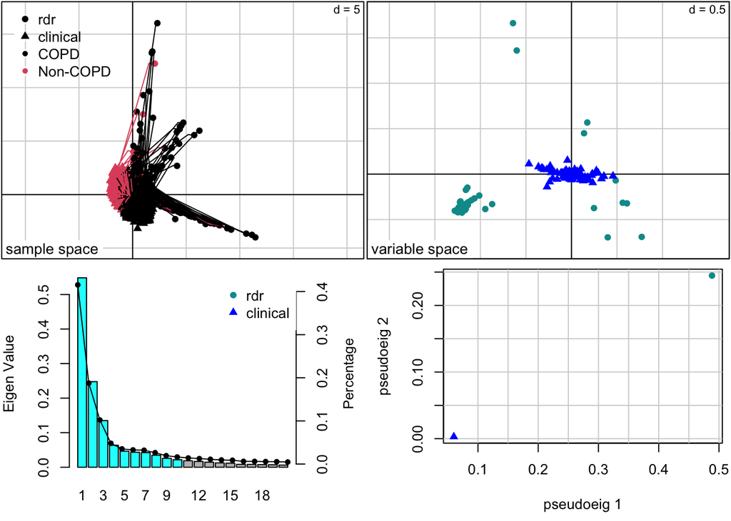

```r
mcoin <- mcia(both_tables, cia.nf=10)
plot(mcoin, axes=1:2, phenovec = class_vector, sample.lab=FALSE, df.color=c("#009999", "#0000FF")) # visualize the result
```

### 7.4 TRTGRP prediction

Now we will use different methods to predict *TRTGRP* with the radiomic features.

Load clinic data and radiomic features. Since they differ in the number of id, we will only keep common ids.

```r
## Radar object
file <- listRDA("rdr_L1_Andrea.rda")
rdr_L1 <- file$rdr_L1
df_rdr <- as.data.frame(assay(rdr_L1))

## Clinic data
clean_data <- read.delim("eclipse_all_CLEAN.txt")
ch <- sapply(clean_data, is.character) # characters to factors
clean_data[ch] <- lapply(clean_data[ch], as.factor)

## Keep common ids
id_in_rdr <- colnames(df_rdr) # id of rdr
id_in_clinical <- rownames(clean_data) # id of clinical
common_id <- Reduce(intersect, list(id_in_rdr,id_in_clinical)) # common id
df_clinical <- clean_data %>% filter(row.names(clean_data) %in% common_id)
df_rdr <- select(df_rdr, one_of(common_id))
```

View a summary of our variable of interest *TRTGRP.t1*:

```r
table(df_clinical$TRTGRP.t1)
```

```
##
##       COPD Subjects Non-smoker Controls     Smoker Controls
##                1763                 193                 271
```

```r
TRTGRP_values <- as.numeric(df_clinical$TRTGRP.t1)
table(TRTGRP_values)
```

```
## TRTGRP_values
##    1    2    3
## 1763  193  271
```

We have three different levels: COPD Subjects Non-smoker, Controls and Smoker Controls. We will combine it into two levels: COPD (cases) and Non COPD (controls).

```r
for(i in 1:length(TRTGRP_values)){
  if(TRTGRP_values[i] == 1) TRTGRP_values[i] <- "COPD"
  else TRTGRP_values[i] <- "Non COPD"
}
table(TRTGRP_values)
```

```
## TRTGRP_values
##     COPD Non COPD
##     1763      464
```

```r
TRTGRP_values <- as.numeric(as.factor(TRTGRP_values))
table(TRTGRP_values)
```

```
## TRTGRP_values
##    1    2
## 1763  464
```

We are interested in predicting *TRTGRP.t1* given the radiomic features. So we will add this variable to the table of radiomic features.

Add the values to the data frame and put id as rows instead of columns:

```r
df_rdr2 <- rbind(df_rdr, "TRTGRP_values" = TRTGRP_values)
df_rdr3 <- as.data.frame(t(df_rdr2))
rownames(df_rdr3) <- colnames(df_rdr2) # put id names
print(as_tibble(df_rdr3))
```

```
## # A tibble: 2,227 × 1,233
##    Elongation.original Flatness.original LeastAxisLength.origi… MajorAxisLength…
##                  <dbl>             <dbl>                  <dbl>            <dbl>
##  1               0.743             0.589                   158.             268.
##  2               0.673             0.636                   181.             285.
##  3               0.628             0.520                   148.             285.
##  4               0.818             0.651                   174.             268.
##  5               0.828             0.644                   187.             290.
##  6               0.836             0.588                   157.             268.
##  7               0.755             0.532                   176.             330.
##  8               0.886             0.515                   168.             326.
##  9               0.694             0.572                   200.             349.
## 10               0.780             0.640                   203.             316.
## # … with 2,217 more rows, and 1,229 more variables:
## #   Maximum2DDiameterColumn.original <dbl>,
## #   Maximum2DDiameterRow.original <dbl>, Maximum2DDiameterSlice.original <dbl>,
## #   Maximum3DDiameter.original <dbl>, MeshVolume.original <dbl>,
## #   MinorAxisLength.original <dbl>, Sphericity.original <dbl>,
## #   SurfaceArea.original <dbl>, SurfaceVolumeRatio.original <dbl>,
## #   VoxelVolume.original <dbl>, `10Percentile.original` <dbl>, …
```

With the data we have, we need to balance the data.

Check how much data we have of each type:

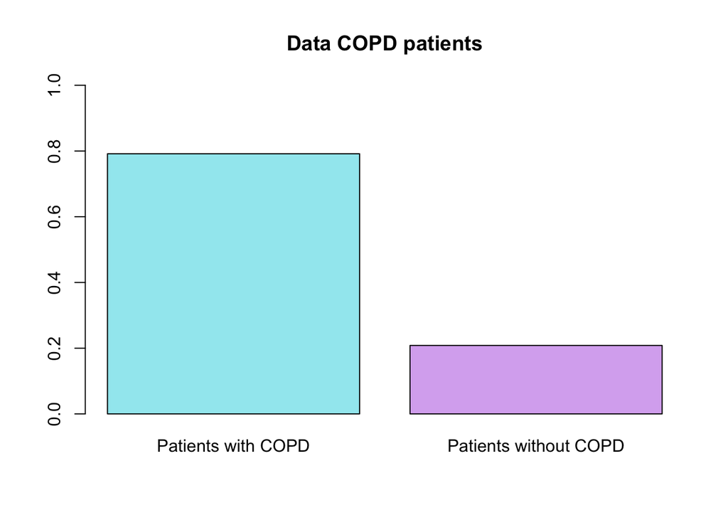

```r
barplot(prop.table(table(TRTGRP_values)), col = c("#a1e9f0", "#d9b1f0"), ylim = c(0, 1), main = "Data COPD patients",
         names = c('Patients with COPD','Patients without COPD'))
```

We can clearly see that we don’t have balanced data, this will produce not very accurate results in our models.

```r
table(df_rdr3$TRTGRP_values)
```

```
##
##    1    2
## 1763  464
```

**Balancing data**

We will use different techniques for balancing data.

- Upsampling: refers to the technique to create artificial or duplicate data points or of the minority class sample to balance the class label.
- SMOTE method (Synthetic Minority Oversampling TEchnique): which is an oversampling technique that aims to balance class distribution by randomly increasing minority class examples by replicating them, generates synthetic data points of minority samples
- Downsampling method: removes or reduces the majority of class samples to balance the class label.

SMOTE:

```r
df_rdr3$TRTGRP_values <- as.factor(df_rdr3$TRTGRP_values)
smote_data <- SMOTE(TRTGRP_values ~ ., data  = df_rdr3)
table(smote_data$TRTGRP_values)
```

```
##
##    1    2
## 1856 1392
```

Upsampling (with caret function):

```r
up_data <- upSample(x = df_rdr3[, -ncol(df_rdr3)], y = df_rdr3$TRTGRP_values)
names(up_data)[names(up_data) == 'Class'] <- 'TRTGRP_values'
table(up_data$TRTGRP_values)
```

```
##
##    1    2
## 1763 1763
```

Downsampling:

```r
down_data <- downSample(x = df_rdr3[, -ncol(df_rdr3)], y = df_rdr3$TRTGRP_values)
names(down_data)[names(down_data) == 'Class'] <- 'TRTGRP_values'
table(down_data$TRTGRP_values)
```

```
##
##   1   2
## 464 464
```

**Boosting**

We create a function that takes as a parameter your entire dataset and returns the accuracy of a boosting model (GBM).

```r
Boosting <- function(data){

  #### Select train 70% and test 30% randomly
  rows <- sample(nrow(data), .7 * nrow(data))
  train_data <- data[rows, ] # train data
  test_data <- data[-rows, ] # test data

  #### Train a model using our training data
  model_gbm <- gbm(TRTGRP_values ~.,
                data = train_data,
                distribution = "multinomial",
                cv.folds = 10,
                shrinkage = .01,
                n.minobsinnode = 10,
                n.trees = 500)       # 500 tress to be built

  #### Make predictions on the test data
  pred_test <- predict.gbm(object = model_gbm,
                   newdata = test_data,
                   n.trees = 500,           # 500 tress to be built
                   type = "response")

  #### Create a confusion matrix:
  class_names <- colnames(pred_test)[apply(pred_test, 1, which.max)]
  result <- data.frame(test_data$TRTGRP_values, class_names)
  conf_mat <- confusionMatrix(as.factor(test_data$TRTGRP_values), as.factor(class_names))

  return(conf_mat$overall["Accuracy"]) # return Accuracy
}
```

First we will do Boosting *without balancing* the data:

```r
(boosting_not_balanced <- Boosting(df_rdr3))
```

```
##  Accuracy
## 0.7922272
```

Balancing our data with *upsampling* method:

```r
(boosting_up <- Boosting(up_data))
```

```
##  Accuracy
## 0.7098299
```

Balancing our data with *SMOTE* method:

```r
(boosting_smote <- Boosting(smote_data))
```

```
## Accuracy
## 0.734359
```

Balancing our data with *downsampling* method:

```r
(boosting_down <- Boosting(down_data))
```

```
##  Accuracy
## 0.6523297
```

**Random Forest**

With Random Forest we can’t have columns starting with numbers, so we will change them and add an A before the number:

```r
df_rdr4 <- df_rdr3
# Columns that start with numbers
names_number <- colnames(df_rdr4 %>% dplyr:: select(starts_with(c("0","1","2","3","4","5","6","7","8","9"))))
# Add and A before the number
names_changed <- unlist(lapply(names_number, function(x) paste("A", x, sep="")))
# Change the names
setnames(df_rdr4, old=names_number, new = names_changed, skip_absent=TRUE)
```

SMOTE:

```r
df_rdr4$TRTGRP_values <- as.factor(df_rdr4$TRTGRP_values)
smote_data_RF <- SMOTE(TRTGRP_values ~ ., data  = df_rdr4)
table(smote_data_RF$TRTGRP_values)
```

```
##
##    1    2
## 1856 1392
```

Upsampling:

```r
up_data_RF <- upSample(x = df_rdr4[, -ncol(df_rdr4)], y = df_rdr4$TRTGRP_values)
names(up_data_RF)[names(up_data_RF) == 'Class'] <- 'TRTGRP_values'
table(up_data_RF$TRTGRP_values)
```

```
##
##    1    2
## 1763 1763
```

Downsampling:

```r
down_data_RF <- downSample(x = df_rdr4[, -ncol(df_rdr4)], y = df_rdr4$TRTGRP_values)
names(down_data_RF)[names(down_data_RF) == 'Class'] <- 'TRTGRP_values'
table(down_data_RF$TRTGRP_values)
```

```
##
##   1   2
## 464 464
```

We create a function that takes as a parameter your entire dataset and returns the accuracy of a Random Forest model.

```r
RandomForest <- function(data){

  #### Select train 70% and test 30% randomly
  rows <- sample(nrow(data), .7 * nrow(data))
  train_data <- data[rows, ]
  test_data <- data[-rows, ]


  #### Train a model using our training data
  model <- randomForest(TRTGRP_values ~ . , data = train_data)


  #### Make predictions on the test data
  predictions <- predict(model, test_data)
  confusion_matrix <- with(test_data, table(predictions, TRTGRP_values))


  #### Accuracy of our model
  accuracy <- sum(diag(confusion_matrix)) / sum(confusion_matrix)
  return(accuracy)
}
```

First we will do Random Forest *without balancing* the data:

```r
(rf_not_balanced <- RandomForest(df_rdr4))
```

```
## [1] 0.7922272
```

Balancing our data with *upsampling* method:

```r
(rf_up <- RandomForest(up_data_RF))
```

```
## [1] 0.9300567
```

Now we balance our data with *SMOTE* method:

```r
(rf_smote <- RandomForest(smote_data_RF))
```

```
## [1] 0.9046154
```

Balancing our data with *downsampling* method:

```r
(rf_down <- RandomForest(down_data_RF))
```

```
## [1] 0.6236559
```

**XGBoost**

We create a function that takes as a parameter your entire dataset and returns the accuracy of a XgBoost model.

```r
XgBoost <- function(data){

  values <- as.factor(data$TRTGRP_values)
  label <- as.integer(data$TRTGRP_values)-1
  data$TRTGRP_values <- NULL

  #### Select train 70% and test 30% randomly
  rows <- sample(nrow(data), .7 * nrow(data))
  train_data <- as.matrix(data[rows, ]) # train data
  train_label <- label[rows]
  test_data <- as.matrix(data[-rows, ]) # test data
  test_label <- label[-rows]


  #### Convert the train and test data into xgboost matrix type
  xgboost_train <- xgb.DMatrix(data=as.matrix(train_data),label=train_label)
  xgboost_test <- xgb.DMatrix(data=as.matrix(test_data),label=test_label)


  #### Train a model using our training data
  xgb.fit <- xgb.train(data = xgboost_train,
                       nrounds=5,
                       num_class=2)


  #### Make predictions on the test data
  predictions <- predict(xgb.fit, xgboost_test)
  predictions <- as.factor(predictions)

  #### Create a confusion matrix:
  conf_mat <- confusionMatrix(as.factor(test_label), predictions)
  return(conf_mat$overall["Accuracy"])
}
```

First we will do XgBoost *without balancing* the data:

```r
(xgboost_not_balanced <- XgBoost(df_rdr3))
```

```
##  Accuracy
## 0.7593423
```

Balancing our data with *upsampling* method:

```r
(xgboost_up <- XgBoost(up_data))
```

```
##  Accuracy
## 0.8374291
```

Now we balance our data with *SMOTE* method:

```r
(xgboost_smote <- XgBoost(smote_data))
```

```
##  Accuracy
## 0.8112821
```

Balancing our data with *downsampling* method:

```r
(xgboost_down <- XgBoost(down_data))
```

```
##  Accuracy
## 0.5949821
```

Summary:

```r
final_results <- data.frame("Boosting" = c(boosting_not_balanced, boosting_smote, boosting_down, boosting_up),
                            "Random Forest" = c(rf_not_balanced, rf_smote, rf_down, rf_up),
                            "XGBoost" = c(xgboost_not_balanced, xgboost_smote, xgboost_down, xgboost_up))
rownames(final_results) <- c("No balancing", "SMOTE", "Down Sample", "Up Sample")
final_results
```

```
##               Boosting Random.Forest   XGBoost
## No balancing 0.7922272     0.7922272 0.7593423
## SMOTE        0.7343590     0.9046154 0.8112821
## Down Sample  0.6523297     0.6236559 0.5949821
## Up Sample    0.7098299     0.9300567 0.8374291
```

Best result:

```r
value <- max(final_results[1:4,1:3])
method <- names(final_results)[which(final_results == max(value), arr.ind=T)[, "col"]]
balancing <- rownames(final_results)[which(final_results == max(value), arr.ind=T)[, "row"]]
print(list(" Maximum Accuracy" = value, " Method" = method, "Balancing" = balancing))
```

```
## $` Maximum Accuracy`
## [1] 0.9300567
##
## $` Method`
## [1] "Random.Forest"
##
## $Balancing
## [1] "Up Sample"
```

### 7.5 Classification COPD types

Now we want to predict 3 different types of COPD.

Load clinic data and radiomic features. Since they differ in the number of id, we will only keep common ids.

```r
## Radar object
file <- listRDA("rdr_L1_Andrea.rda")
rdr_L1 <- file$rdr_L1
df_rdr <- as.data.frame(assay(rdr_L1))

## Clinic data
clean_data <- read.delim("eclipse_all_CLEAN.txt")
ch <- sapply(clean_data, is.character) # characters to factors
clean_data[ch] <- lapply(clean_data[ch], as.factor)

## Keep common ids
id_in_rdr <- colnames(df_rdr) # id of rdr
id_in_clinical <- rownames(clean_data) # id of clinical
common_id <- Reduce(intersect, list(id_in_rdr,id_in_clinical)) # common id
df_clinical <- clean_data %>% filter(row.names(clean_data) %in% common_id)
df_rdr <- select(df_rdr, one_of(common_id))
```

View a summary of our variable of interest *GOLDCD*:

```r
table(df_clinical$GOLDCD)
```

```
##
##   2   3   4   9
## 784 740 239 464
```

There’s *COPD_2*, *COPD_3* and *COPD_4.* *COPD_9* refers to patients that don’t have COPD (*Non-smoker Controls* and *Smoker Controls*).

Now we will rename the variables name. We want to predict different types of COPD, so we delete the *COPD_9*.

```r
df_clinical_COPD <- df_clinical[df_clinical$GOLDCD != 9, ] # delete non COPD subjects
df_clinical_COPD$TRTGRP.t1 <- NULL # delete TRTGRP.t1 has only value COPD Subjects

# Change names
for(i in 1:length(df_clinical_COPD$GOLDCD)){
  if(df_clinical_COPD$GOLDCD[i] == 2) df_clinical_COPD$GOLDCD[i] <- "COPD_2"
  if(df_clinical_COPD$GOLDCD[i] == 3) df_clinical_COPD$GOLDCD[i] <- "COPD_3"
  if(df_clinical_COPD$GOLDCD[i] == 4) df_clinical_COPD$GOLDCD[i] <- "COPD_4"
}

table(df_clinical_COPD$GOLDCD)
```

```
##
## COPD_2 COPD_3 COPD_4
##    784    740    239
```

We will add this variable to the table of radiomic features.

```r
COPD_values <- as.numeric(as.factor(df_clinical_COPD$GOLDCD)) # convert to numeric
df_rdr_COPD <- select(df_rdr, one_of(rownames(df_clinical_COPD))) # select patients in rdr that have COPD
df_rdr4 <- rbind(df_rdr_COPD, "COPD_values" = COPD_values) # add COPD to radiomic features
df_rdr5 <- as.data.frame(t(df_rdr4))
rownames(df_rdr5) <- colnames(df_rdr4) # put id names
table(df_rdr5$COPD_values)
```

```
##
##   1   2   3
## 784 740 239
```

Check how much data we have of each type:

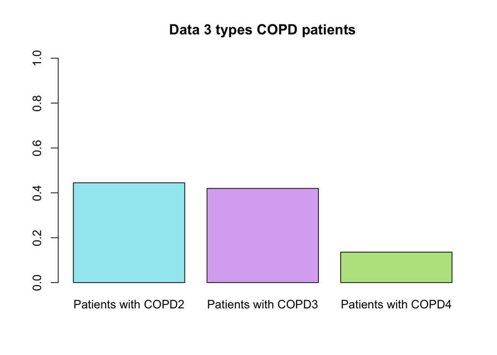

```r
barplot(prop.table(table(COPD_values)), col = c("#a1e9f0", "#d9b1f0","#b9e38d"), ylim = c(0, 1), main = "Data 3 types COPD patients",
         names = c('Patients with COPD2','Patients with COPD3', 'Patients with COPD4'))
```

We don’t have balanced data, specially for *COPD_4*.

We will repeat the same steps to predict this variable as we did in the section before.

SMOTE:

```r
set.seed(123)
df_rdr5$COPD_values <- as.factor(df_rdr5$COPD_values)
smote_data_Types <- SMOTE(COPD_values ~ ., data  = df_rdr5)
table(smote_data_Types$COPD_values)
```

```
##
##   1   2   3
## 445 511 717
```

Upsampling (with caret function):

```r
up_data_Types <- upSample(x = df_rdr5[, -ncol(df_rdr5)], y = df_rdr5$COPD_values)
names(up_data_Types)[names(up_data_Types) == 'Class'] <- 'COPD_values'
table(up_data_Types$COPD_values)
```

```
##
##   1   2   3
## 784 784 784
```

Downsampling:

```r
down_data_Types <- downSample(x = df_rdr5[, -ncol(df_rdr5)], y = df_rdr5$COPD_values)
names(down_data_Types)[names(down_data_Types) == 'Class'] <- 'COPD_values'
table(down_data_Types$COPD_values)
```

```
##
##   1   2   3
## 239 239 239
```

**Boosting**

```r
Boosting2 <- function(data){

  #### Select train 70% and test 30% randomly
  rows <- sample(nrow(data), .7 * nrow(data))
  train_data <- data[rows, ] # train data
  test_data <- data[-rows, ] # test data

  #### Train a model using our training data
  model_gbm <- gbm(COPD_values ~.,
                data = train_data,
                distribution = "multinomial",
                cv.folds = 10,
                shrinkage = .01,
                n.minobsinnode = 10,
                n.trees = 500)       # 500 tress to be built

  #### Make predictions on the test data
  pred_test <- predict.gbm(object = model_gbm,
                   newdata = test_data,
                   n.trees = 500,           # 500 tress to be built
                   type = "response")

  #### Create a confusion matrix:
  class_names <- colnames(pred_test)[apply(pred_test, 1, which.max)]
  result <- data.frame(test_data$COPD_values, class_names)
  conf_mat <- confusionMatrix(as.factor(test_data$COPD_values), as.factor(class_names))

  return(conf_mat$overall["Accuracy"]) # return Accuracy
}
```

First we will do Boosting *without balancing* the data:

```r
(boosting_not_balanced2 <- Boosting2(df_rdr5))
```

```
##  Accuracy
## 0.5897921
```

Balancing our data with *upsampling* method:

```r
(boosting_up2 <- Boosting2(up_data_Types))
```

```
##  Accuracy
## 0.5679887
```

Balancing our data with *SMOTE* method:

```r
(boosting_smote2 <- Boosting2(smote_data_Types))
```

```
##  Accuracy
## 0.6314741
```

Balancing our data with *downsampling* method:

```r
(boosting_down2 <- Boosting2(down_data_Types))
```

```
##  Accuracy
## 0.5231481
```

**Random Forest**

```r
# With Random Forest we can't have columns starting with numbers, so we will change them and add an A before the number
df_rdr6 <- df_rdr5
# Columns that start with numbers
names_number <- colnames(df_rdr6 %>% dplyr:: select(starts_with(c("0","1","2","3","4","5","6","7","8","9"))))
# Add and A before the number
names_changed <- unlist(lapply(names_number, function(x) paste("A", x, sep="")))
# Change the names
setnames(df_rdr6, old=names_number, new = names_changed, skip_absent=TRUE)
```

SMOTE:

```r
set.seed(123)
df_rdr6$COPD_values <- as.factor(df_rdr6$COPD_values)
smote_data_Types_RF <- SMOTE(COPD_values ~ ., data  = df_rdr6)
table(smote_data_Types_RF$COPD_values)
```

```
##
##   1   2   3
## 445 511 717
```

Upsampling (with caret function):

```r
up_data_Types_RF <- upSample(x = df_rdr6[, -ncol(df_rdr6)], y = df_rdr6$COPD_values)
names(up_data_Types_RF)[names(up_data_Types_RF) == 'Class'] <- 'COPD_values'
table(up_data_Types_RF$COPD_values)
```

```
##
##   1   2   3
## 784 784 784
```

Downsampling:

```r
down_data_Types_RF <- downSample(x = df_rdr6[, -ncol(df_rdr6)], y = df_rdr6$COPD_values)
names(down_data_Types_RF)[names(down_data_Types_RF) == 'Class'] <- 'COPD_values'
table(down_data_Types_RF$COPD_values)
```

```
##
##   1   2   3
## 239 239 239
```

```r
RandomForest2 <- function(data){

  #### Select train 70% and test 30% randomly
  rows <- sample(nrow(data), .7 * nrow(data))
  train_data <- data[rows, ]
  test_data <- data[-rows, ]


  #### Train a model using our training data
  model <- randomForest(COPD_values ~ . , data = train_data)


  #### Make predictions on the test data
  predictions <- predict(model, test_data)
  confusion_matrix <- with(test_data, table(predictions, COPD_values))


  #### Accuracy of our model
  accuracy <- sum(diag(confusion_matrix)) / sum(confusion_matrix)
  return(accuracy)
}
```

First we will do Random Forest *without balancing* the data:

```r
(rf_not_balanced2 <- RandomForest2(df_rdr6))
```

```
## [1] 0.5727788
```

Balancing our data with *upsampling* method:

```r
(rf_up2 <- RandomForest2(up_data_Types_RF))
```

```
## [1] 0.7152975
```

Now we balance our data with *SMOTE* method:

```r
(rf_smote2 <- RandomForest2(smote_data_Types_RF))
```

```
## [1] 0.7788845
```

Balancing our data with *downsampling* method:

```r
(rf_down2 <- RandomForest2(down_data_Types_RF))
```

```
## [1] 0.462963
```

**XGBoost**

```r
XgBoost2 <- function(data){

  values <- as.factor(data$COPD_values)
  label <- as.integer(data$COPD_values)-1
  data$COPD_values <- NULL

  #### Select train 70% and test 30% randomly
  rows <- sample(nrow(data), .7 * nrow(data))
  train_data <- as.matrix(data[rows, ]) # train data
  train_label <- label[rows]
  test_data <- as.matrix(data[-rows, ]) # test data
  test_label <- label[-rows]


  #### Convert the train and test data into xgboost matrix type
  xgboost_train <- xgb.DMatrix(data=as.matrix(train_data),label=train_label)
  xgboost_test <- xgb.DMatrix(data=as.matrix(test_data),label=test_label)


  #### Train a model using our training data
  xgb.fit <- xgb.train(data = xgboost_train,
                       nrounds=5,
                       num_class=3)


  #### Make predictions on the test data
  predictions <- predict(xgb.fit, xgboost_test)
  predictions <- as.factor(predictions)

  #### Create a confusion matrix:
  conf_mat <- confusionMatrix(as.factor(test_label), predictions)
  return(conf_mat$overall["Accuracy"])

}
```

First we will do XgBoost *without balancing* the data:

```r
(xgboost_not_balanced2 <- XgBoost2(df_rdr5))
```

```
##  Accuracy
## 0.5614367
```

Balancing our data with *upsampling* method:

```r
(xgboost_up2 <- XgBoost2(up_data_Types))
```

```
## Accuracy
## 0.684136
```

Now we balance our data with *SMOTE* method:

```r
(xgboost_smote2 <- XgBoost2(smote_data_Types))
```

```
##  Accuracy
## 0.7430279
```

```r
(xgboost_down2 <- XgBoost2(down_data_Types))
```

```
##  Accuracy
## 0.4537037
```

Summary of the final results:

```r
final_results2 <- data.frame("Boosting" = c(boosting_not_balanced2, boosting_smote2, boosting_down2, boosting_up2),
                            "Random Forest" = c(rf_not_balanced2, rf_smote2, rf_down2, rf_up2),
                            "XGBoost" = c(xgboost_not_balanced2, xgboost_smote2, xgboost_down2, xgboost_up2))
rownames(final_results2) <- c("No balancing", "SMOTE", "Down Sample", "Up Sample")
final_results2
```

```
##               Boosting Random.Forest   XGBoost
## No balancing 0.5897921     0.5727788 0.5614367
## SMOTE        0.6314741     0.7788845 0.7430279
## Down Sample  0.5231481     0.4629630 0.4537037
## Up Sample    0.5679887     0.7152975 0.6841360
```

Best result:

```r
value2 <- max(final_results2[1:4,1:3])
method2 <- names(final_results2)[which(final_results2 == max(value2), arr.ind=T)[, "col"]]
balancing2 <- rownames(final_results2)[which(final_results2 == max(value2), arr.ind=T)[, "row"]]
print(list(" Maximum Accuracy" = value2, " Method" = method2, "Balancing" = balancing2))
```

```
## $` Maximum Accuracy`
## [1] 0.7788845
##
## $` Method`
## [1] "Random.Forest"
##
## $Balancing
## [1] "SMOTE"
```